# RAVED: Differential Expression Analysis for Gene Expression Microarry Data -- GSE4917 dex_24hr vs control_24hr

Mengyuan Kan (mengykan@pennmedicine.upenn.edu)

24 December, 2021

This report shows the differential analysis for gene expression microarry data from GEO study, including:

- Raw probe intensity normalization
- Differential expression
- Adjusting for batch effect

Input:

A pre-prepared phenotype file contains GEO_ID, Tissue, Disease and Treatment information.

Outputs:

- Gene differential expression result file(s) (.csv)
- A gene expression analysis report (.html)

Mannually change the variables for GEO ID (geo_id), data directory (datadir), result directory (resdir), tissue, disease/treatment status, and comparison conditions

```r
# GEO id
geo_id="GSE4917"
# direcotry stores GEO data
datadir="data"
# directory stores generated files
resdir="results"
# tissue
tissue="MCF10A-Myc" # naming is rigid, should be same as the Tissue defined in QC
# reference condition
con0="control_24hr" # naming is rigid, should be same as the Treatment defined in QC
# altered condition
con1="dex_24hr" # naming is rigid, should be same as the Treatment defined in QC
# treatment. Assign "comparison" if this column is used for DE.
treatment=c(con0,con1)
# disease. Assign "comparison" if this column is used for DE.
disease="nonasthma"
```

Manually change these variables according to dataset: **Note that** four variables, platform (platform), geo_GPL (GPL id for analysis if the samples in the study were scanned on multiple platforms), usesuppl (whether to use supplementary data for DE analysis), and normdata (whether the expression matrix is normalized), need to be **manually** defined based on the QC reports. A shortname_func function is suggested to be updated.

```r
platform="Affymetrix"
geo_GPL=""
usesuppl=TRUE
normdata=FALSE
# The shortname_func function shortens the sample name shown in the plots. To start, define shortname_func <- function(x){x}
shortname_func <- function(x){gsub("^(.*).(cel|CEL).gz","\\1",x)} # remove .cel.gz or .CEL.gz from sample
```

Automatically generate phenotype file variable pheno_fn if it is generated from QC step, otherwise manually assign this variable.

```
## pheno_fn = 'results/GSE4917_Phenotype_withQC.txt'
```

Install the prerequisite R packages if they do not exist

- GEOquery
- oligo
- limma
- sva
- annotate
- DT
- corresponding Bioconductor annotationData Packages
- viridis (heatmap color)
- ggplot2
- gplots (heatmap2 plot)
- devtools (compute pca)
- pander
- fgsea
- biomaRt

Load the necessary libraries

## Obtain Phenotype and GEO Data

### Phenotype data preparation

Read in pre-prepared phenotype data

Subset phenotypes based on the comparison variables. Check variables (before and after QC if outliers are detected).

Define paired variable.

If the same donors underwent treated and untreated condition, gene expression pattens are likely influenced by the same donor. Therefore, in this case, we adjust for Donor in limma regression as well as in sva batch-effect adjustment where both scan date and donor will be used as a known covariate (if donor is not correlated with scan date). For treatments/medication received by different patient groups, donor will not be adjusted.

```
## paired = TRUE
```

Exclude samples missing the other paired donors in treatment comparisons if paired analysis is applied

Summary of subsetted samples

| ScanDate_Group | Status | Counts |
| --- | --- | --- |
| 04/13/05 | control_24hr | 1 |
| 05/23/02 | control_24hr | 0 |
| 05/31/02 | control_24hr | 2 |
| 04/13/05 | dex_24hr | 1 |
| 05/23/02 | dex_24hr | 1 |
| 05/31/02 | dex_24hr | 1 |

Summary of the comparison

| **GEO_ID** | GSE4917 |
| --- | --- |
| **Tissue** | MCF10A-Myc |
| **App** | Treatment |
| **Disease** | nonasthma |
| **Treatment** | dex_24hr |
| **N_Condition0** | 3 |
| **N_Condition1** | 3 |
| **Total** | 6 |
| **Unique_ID** | GSE4917_MCF10A-Myc_nonasthma_dex_24hr_vs_control_24hr |

Assign colours to status and scan date (if available)

### Gene expression data preparation

For data from Affymetrix platform, raw probe intensity data from supplementary files (usually .cel files) in GEO are downloaded and used for DE analysis. For data from Agilent platform, the intensity data is derived from GEO expression matrix.

Generate raw.data object using expression matrix from GEO (for platforms other than Affymetrix).

Obtain raw.data.of.interest by subsetting raw.data based on the phenotype of interest

Show expression dataset features

```
## ExpressionFeatureSet (storageMode: lockedEnvironment)
## assayData: 506944 features, 6 samples
##   element names: exprs
## protocolData
##   rowNames: GSM109210.cel.gz GSM109211.cel.gz ... GSM109227.CEL.gz (6
##     total)
##   varLabels: exprs dates
##   varMetadata: labelDescription channel
## phenoData
##   rowNames: GSM109210.cel.gz GSM109211.cel.gz ... GSM109227.CEL.gz (6
##     total)
##   varLabels: GEO_ID Donor ... Status (13 total)
##   varMetadata: labelDescription channel
## featureData: none
## experimentData: use 'experimentData(object)'
## Annotation: pd.hg.u133a
```

## Differential Gene Expression Analysis

### Normalize raw gene expression data

Normalize gene expression raw data using robust multi-array average (RMA) method (if supplementary data is available) or quantile normalize (if use expression matrix), unless the raw.data object is already normalized (based on the variable normdata).

If negative/zero intensity values are present, convert them to NAs.

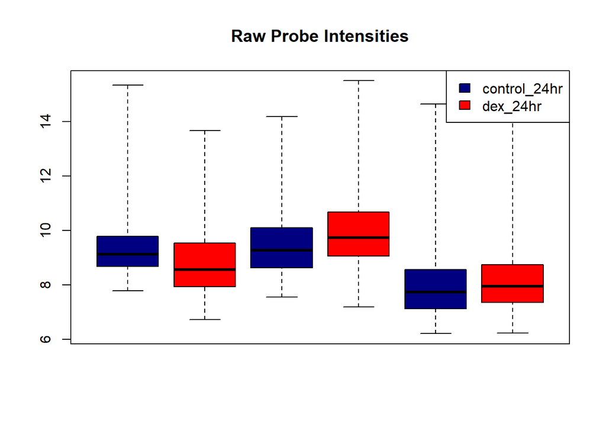

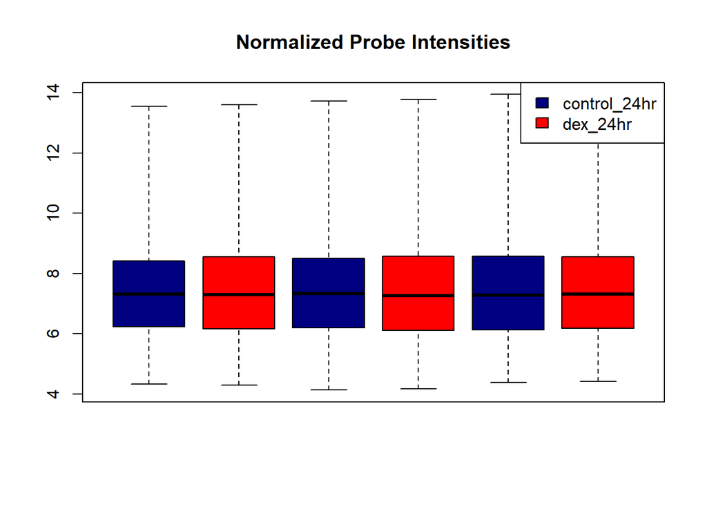

### Pairwise Comparison between Status

Fit a linear model to RMA log-intensity values, fit this model to a contrast matrix for the comparison of interest, and apply empirical Bayes smoothing to obtain more precise standard errors.

Donor is adjusted in this regression

A design model matrix for linear model

| Sample | control_24hr | dex_24hr | rep2 | rep3 |
| --- | --- | --- | --- | --- |
| GSM109210 | 1 | 0 | 0 | 0 |
| GSM109211 | 0 | 1 | 0 | 0 |
| GSM109218 | 1 | 0 | 1 | 0 |
| GSM109219 | 0 | 1 | 1 | 0 |
| GSM109226 | 1 | 0 | 0 | 1 |
| GSM109227 | 0 | 1 | 0 | 1 |

A contract matrix for comparison

|  | dex_24hr-control_24hr |
| --- | --- |
| **control_24hr** | -1 |
| **dex_24hr** | 1 |
| **rep2** | 0 |
| **rep3** | 0 |

### Adjusting for Batch Effect

Check whether to adjust for scan date and donor. Create a full model that includes all variables and a null model that only includes the batch variable. Note that as SVA computes the matrix x in t(batch model)%*%x=batch model, batch effect can be adjusted only when the solve function works.

**The batch used for adjustment:**

```
## batcherror = correlate_donor_scandate
```

Scan date and donor are highly confounded. See the matrix below.

Null model matrix with scan date and donor

| Intercept | 05/23/02 | 05/31/02 | rep2 | rep3 |
| --- | --- | --- | --- | --- |
| 1 | 0 | 1 | 0 | 0 |
| 1 | 1 | 0 | 0 | 0 |
| 1 | 0 | 1 | 1 | 0 |
| 1 | 0 | 1 | 1 | 0 |
| 1 | 0 | 0 | 0 | 1 |
| 1 | 0 | 0 | 0 | 1 |

Compute F statistic p-values adjusted for batch effect. Q-values are obtained by the Benjamini-Hochberg method. If the batch and the status are correlated, assign NA to the batch adjusted p- and q-values. If there is no batch variable or only one batch, assign p- and q-values computed by limma to the batch adjusted p-values

dex_24hr vs. control_24hr summary

| ID | logFC | AveExpr | t | P.Value | adj.P.Val | B | qValuesBatch | pValuesBatch |
| --- | --- | --- | --- | --- | --- | --- | --- | --- |
| Length:22283 | Min. :-2.38693 | Min. : 4.317 | Min. :-10.64586 | Min. :0.0000005 | Min. :0.01096 | Min. :-6.162 | Mode:logical | Mode:logical |
| Class :character | 1st Qu.:-0.11406 | 1st Qu.: 6.197 | 1st Qu.: -0.81307 | 1st Qu.:0.1546285 | 1st Qu.:0.61835 | 1st Qu.:-6.063 | NA's:22283 | NA's:22283 |
| Mode :character | Median : 0.01177 | Median : 7.304 | Median : 0.08374 | Median :0.3932272 | Median :0.78636 | Median :-5.725 | NA | NA |
| NA | Mean : 0.02009 | Mean : 7.451 | Mean : 0.12283 | Mean :0.4289621 | Mean :0.76072 | Mean :-5.323 | NA | NA |
| NA | 3rd Qu.: 0.14752 | 3rd Qu.: 8.505 | 3rd Qu.: 1.01350 | 3rd Qu.:0.6838634 | 3rd Qu.:0.91171 | 3rd Qu.:-4.955 | NA | NA |
| NA | Max. : 3.98445 | Max. :13.733 | Max. : 21.52241 | Max. :0.9999274 | Max. :0.99993 | Max. : 4.158 | NA | NA |

### Assign Official Gene Symbol

Annotate official gene symbol to probes. Install the [R annotation database package](https://bioconductor.org/packages/3.7/data/annotation/) corresponding to your gene expression data. For any newly installed annotation databases, it can be added to the list anno_list reserved for future use.

If using GPL annotation from GEO, note that gene symbol annotation in different GPL may have different column names.

```
## The platform used is pd.hg.u133a
```

```
## The corresponding R annotation database package is hgu133a.db
```

## Gene Expression Results Visualization

### Volcano Plots

Volcano plot (probes with a q-value <0.05 are present in red)

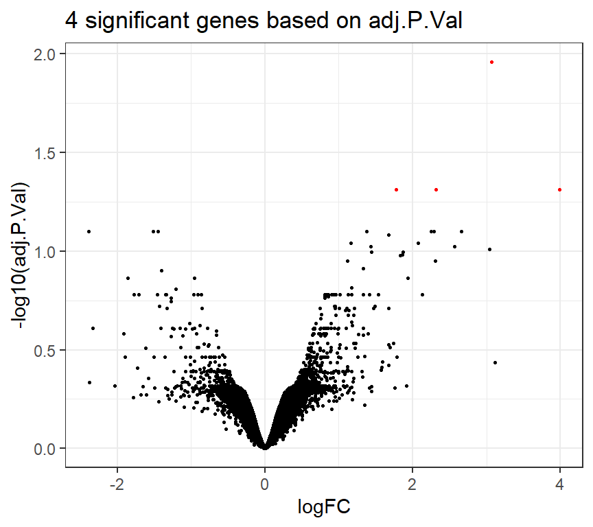

### Histograms

Histograms of p-value distributions

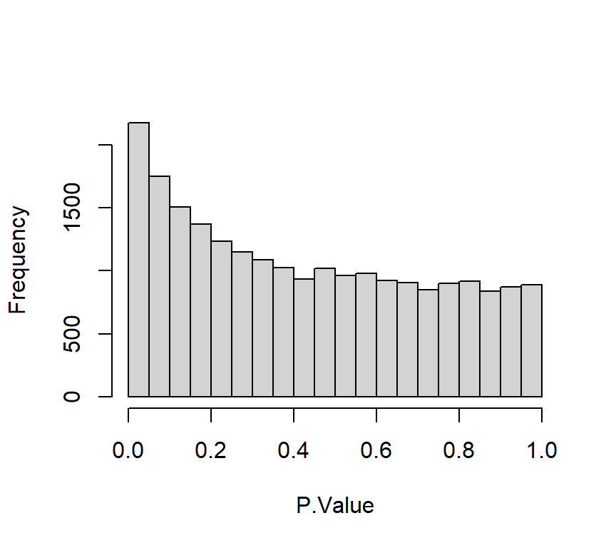

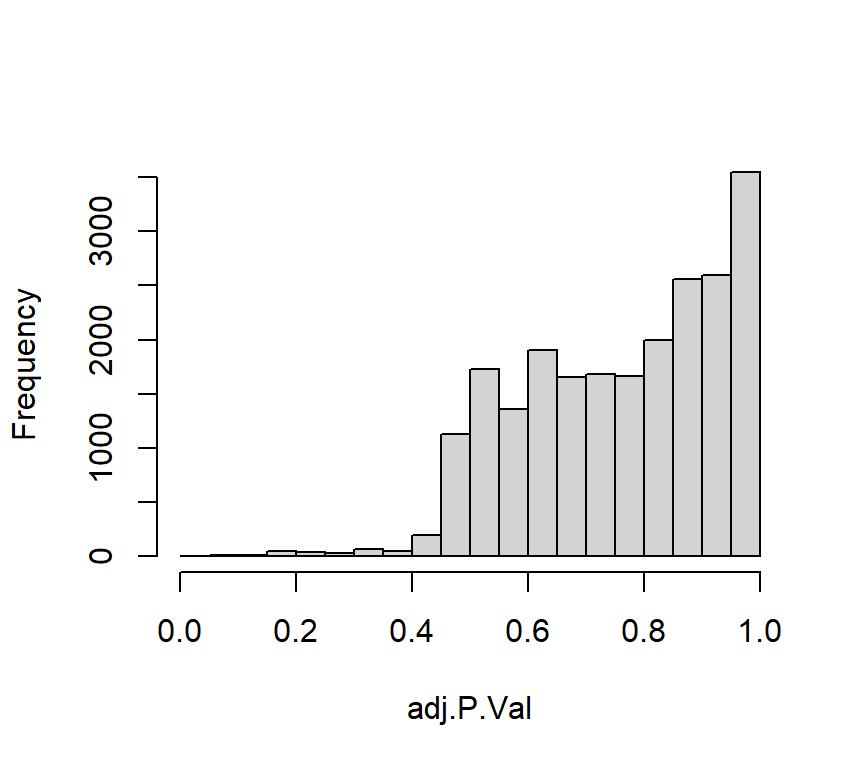

### Top 50 Differentially Expression Results

Show top 50 probes sorted by un-adjusted p-values

| ID | logFC | AveExpr | t | P.Value | adj.P.Val | B | qValuesBatch | pValuesBatch | SYMBOL |
| --- | --- | --- | --- | --- | --- | --- | --- | --- | --- |
| 202149_at | 3.07 | 8.55 | 21.52 | 4.9e-07 | 1.1e-02 | 4.16 | NA | NA | NEDD9 |
| 204602_at | 3.98 | 9.3 | 14.11 | 6.3e-06 | 4.9e-02 | 3.25 | NA | NA | DKK1 |
| 219230_at | 2.31 | 7.16 | 13.77 | 7.3e-06 | 4.9e-02 | 3.18 | NA | NA | TMEM100 |
| 205097_at | 1.77 | 8.06 | 13.38 | 8.7e-06 | 4.9e-02 | 3.1 | NA | NA | SLC26A2 |
| 202150_s_at | 2.29 | 9.09 | 11.58 | 2.1e-05 | 7.9e-02 | 2.64 | NA | NA | NEDD9 |
| 206766_at | 1.37 | 9.89 | 10.69 | 3.3e-05 | 7.9e-02 | 2.37 | NA | NA | ITGA10 |
| 217388_s_at | -1.44 | 9.04 | -10.65 | 3.4e-05 | 7.9e-02 | 2.35 | NA | NA | KYNU |
| 217996_at | -2.39 | 7.39 | -10.55 | 3.6e-05 | 7.9e-02 | 2.32 | NA | NA | PHLDA1 |
| 213338_at | -1.51 | 10.02 | -10.53 | 3.6e-05 | 7.9e-02 | 2.31 | NA | NA | TMEM158 |
| 212741_at | 2.66 | 9.59 | 10.48 | 3.7e-05 | 7.9e-02 | 2.3 | NA | NA | MAOA |

[output cut: 40 more lines]

### Boxplots for Top 6 Differentially Expressed Genes

This step helps to visualize and check the effect direction in the comparison.

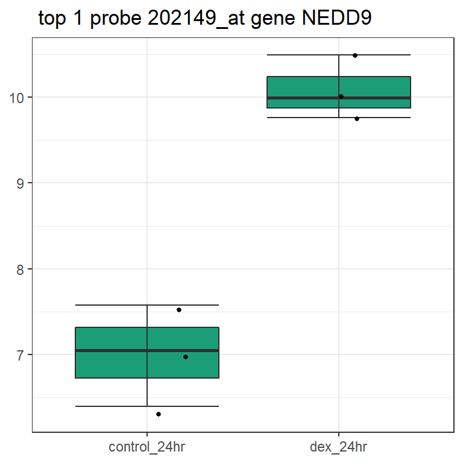

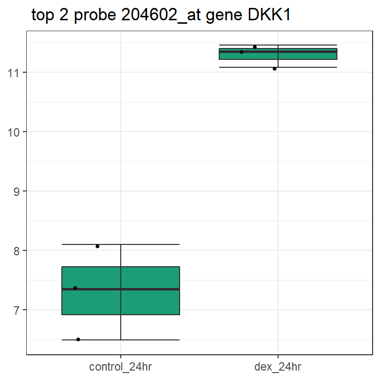

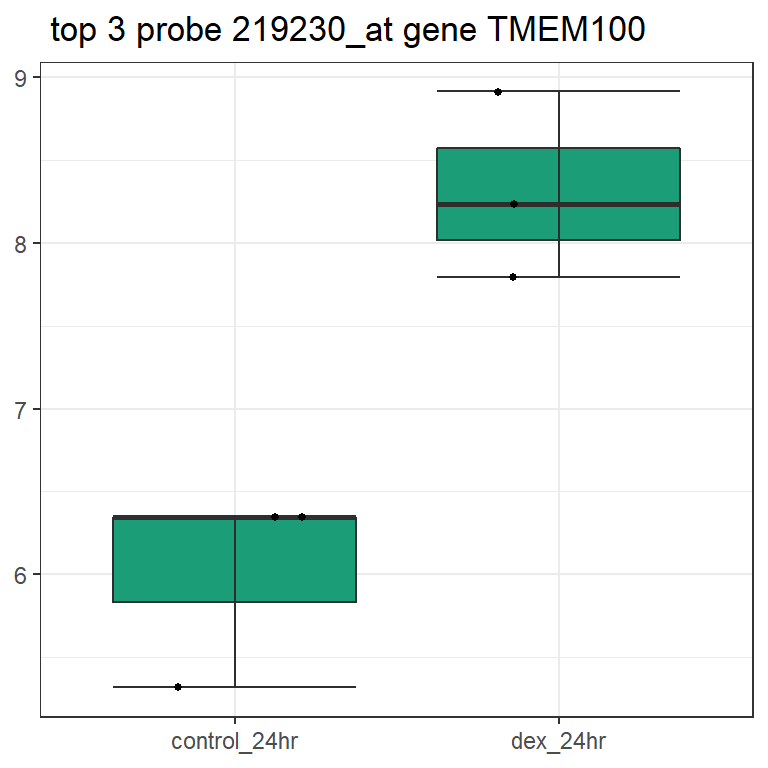

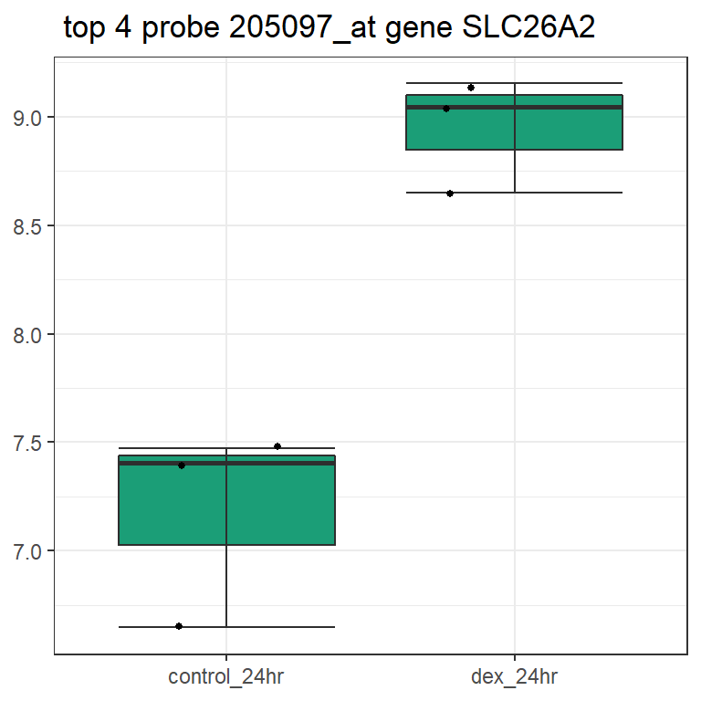

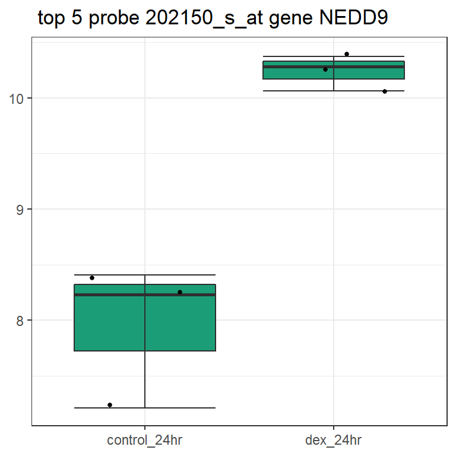

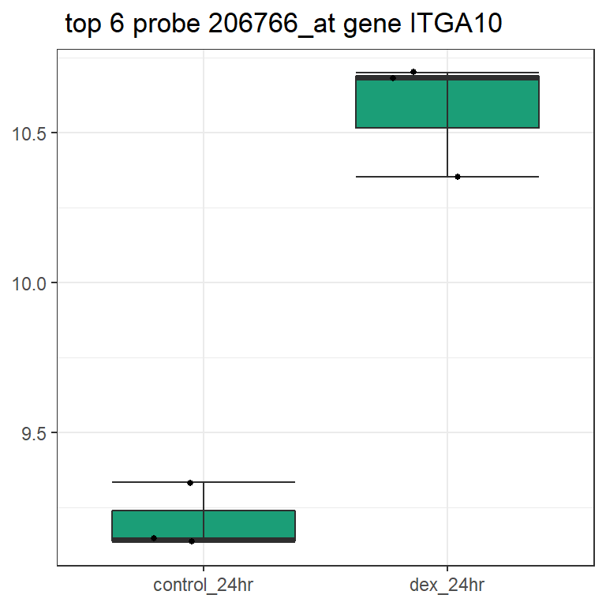

### Heatmap for Top 200 Differentially Expressed Genes

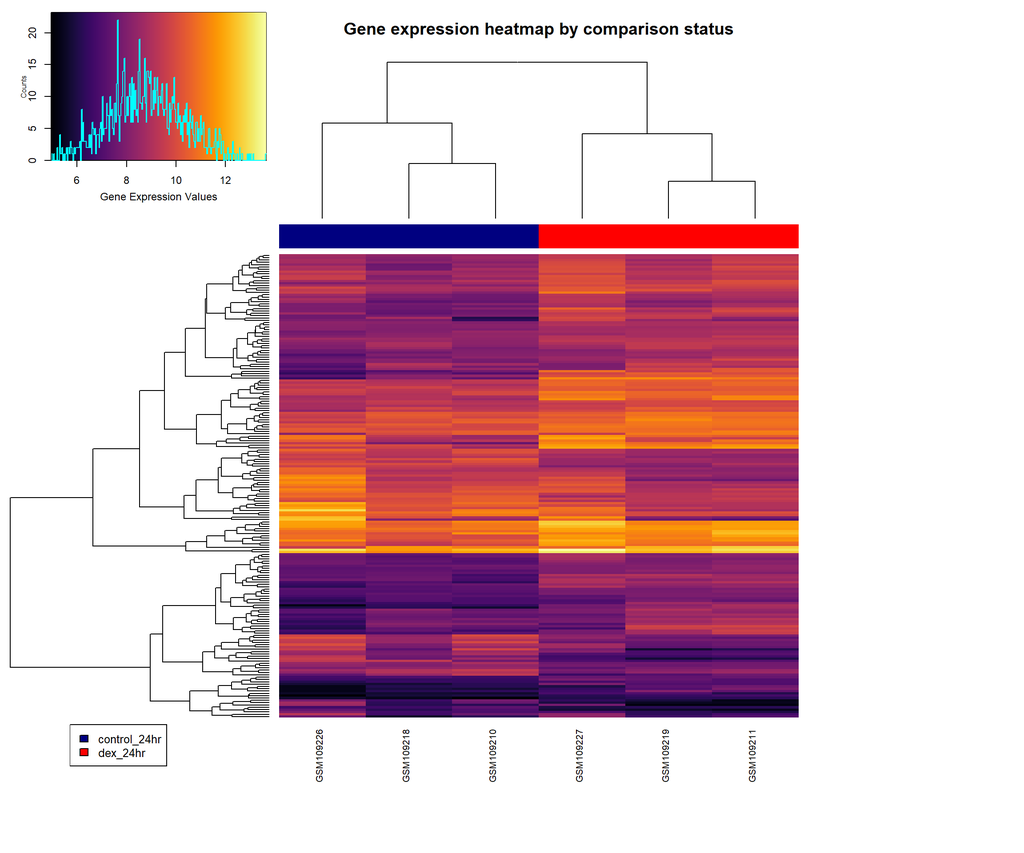

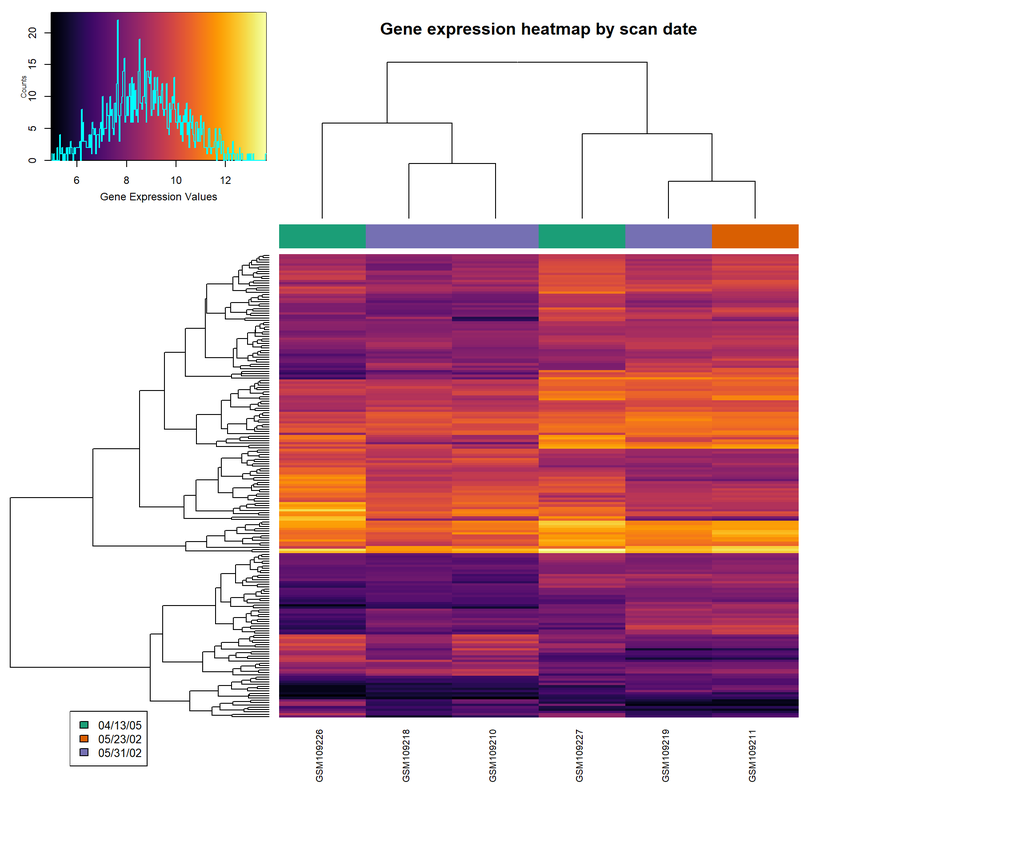

### Heatmap for Sample Correlation

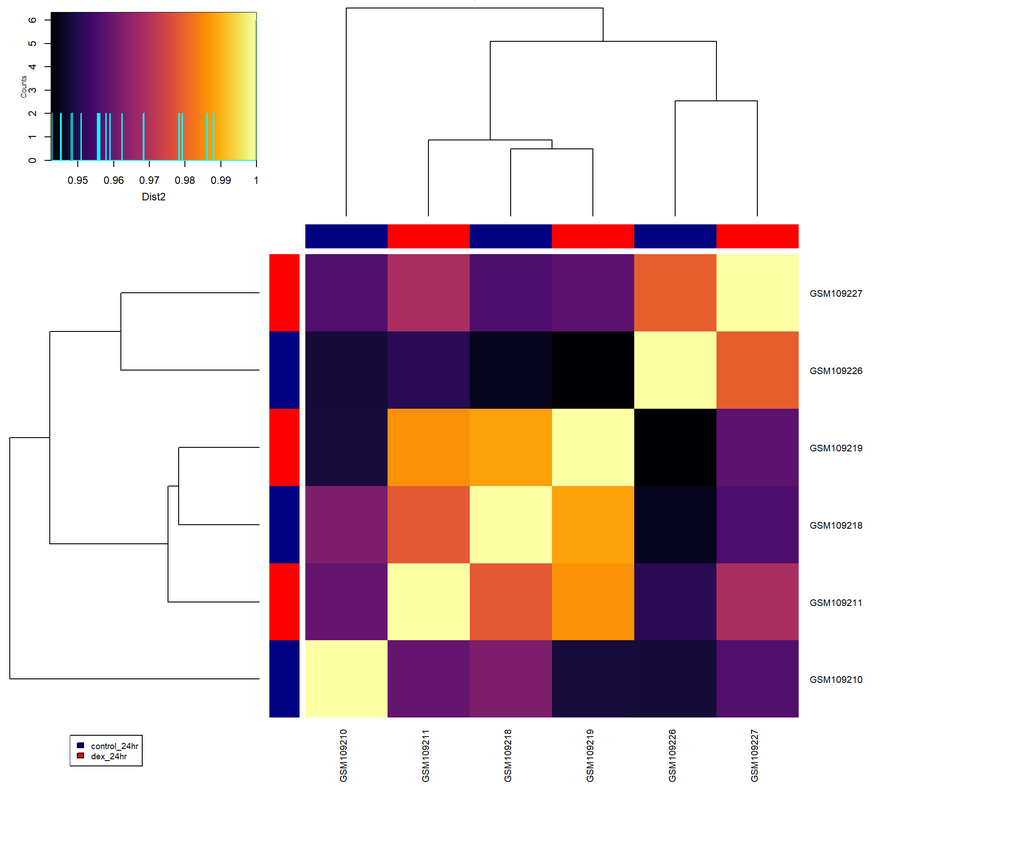

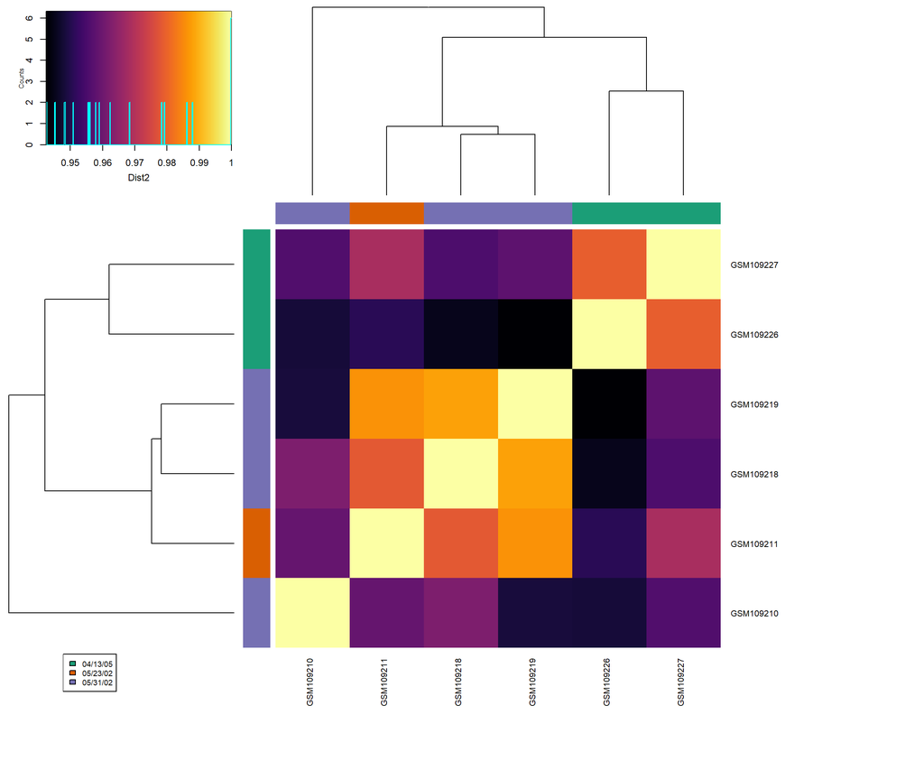

### Principal Component Analysis (PCA)

1. Compute PCs and variance explained by the first 10 PCs

Variance explained

| PC | Proportion of Variance (%) | Cumulative Proportion of Variance (%) |
| --- | --- | --- |
| PC1 | 36.33 | 36.33 |
| PC2 | 31.74 | 68.07 |
| PC3 | 13.43 | 81.5 |
| PC4 | 10.79 | 92.3 |
| PC5 | 7.702 | 100 |
| PC6 | 9.15e-28 | 100 |

2. PCA plots

PCA plots are generated using the first two principle components colored by known factors (e.g. comparison status, donors and scan dates), visualizing similarities between arrays and these similarities' correlation to batch effects.

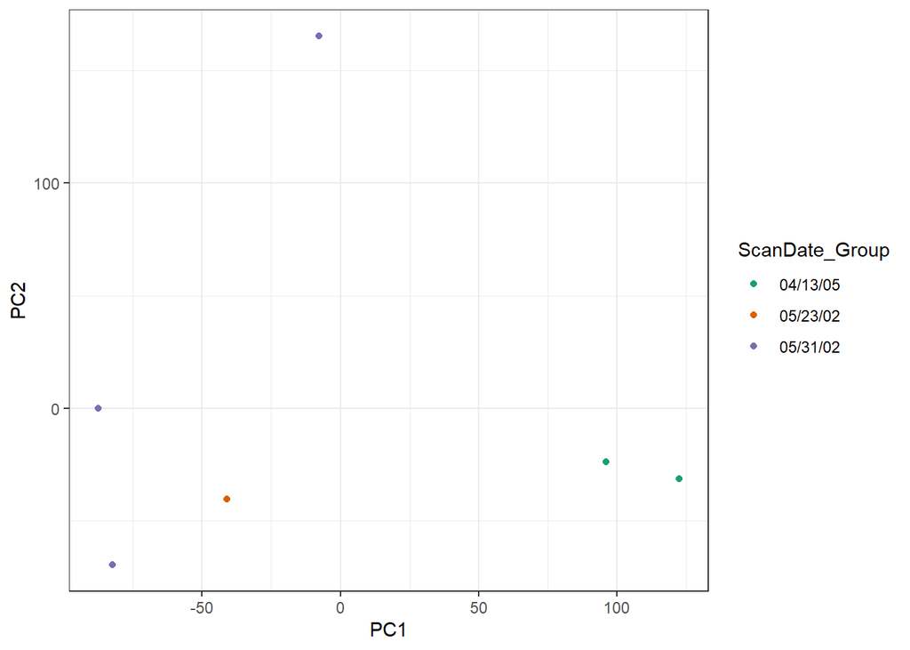

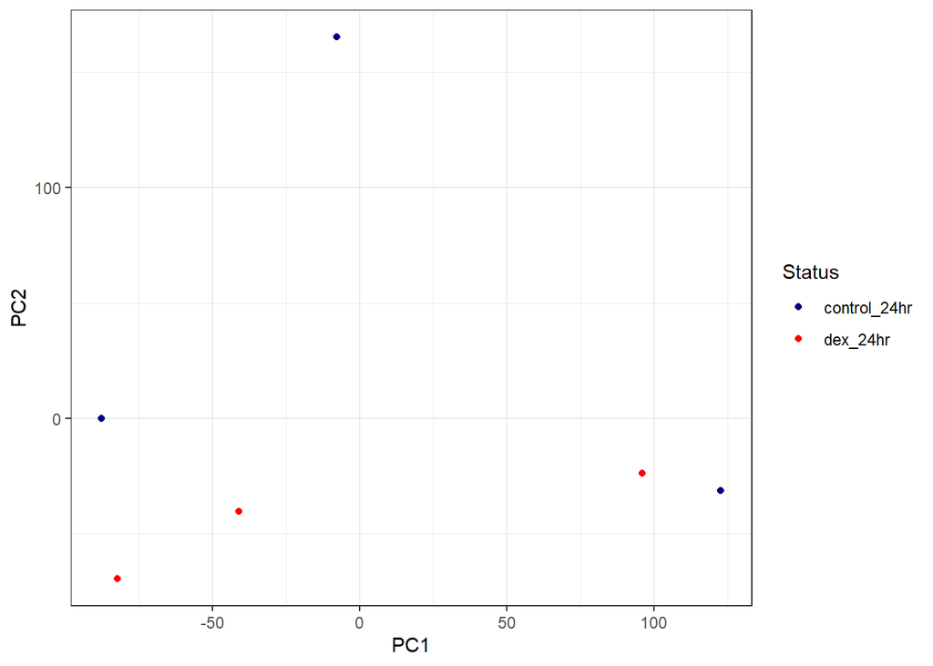

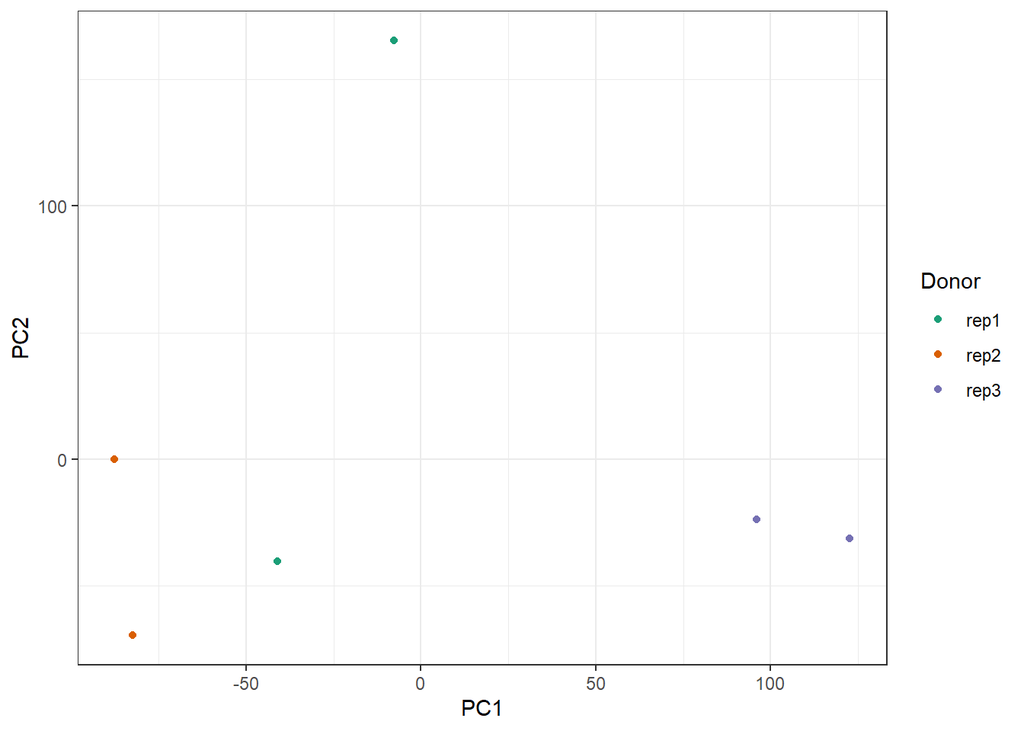

### Gene-Set Enrichment Analysis (GSEA)

Generate a vector of genes with z-statistics. Keep only one probe with the smallest p-value and the largest absolute log2 fold change if there are multiple probes mapped to the same gene.

Run GSEA with the fgsea function.

View top pathways in fgsea results. Only include the first five leading genes

```
## 75 main pathways are significant.
```

| pathway | pval | padj | ES | NES | nMoreExtreme | size | main_pathway | leadingEdge |
| --- | --- | --- | --- | --- | --- | --- | --- | --- |
| KEGG_VALINE_LEUCINE_AND_ISOLEUCINE_DEGRADATION | 0.0002 | 0.0055 | 0.625 | 2.265 | 0 | 41 | main | AOX1,ALDH6A1,DBT,ACAT1,HADH |
| KEGG_UBIQUITIN_MEDIATED_PROTEOLYSIS | 0.0001 | 0.0055 | 0.489 | 2.154 | 0 | 114 | main | BIRC3,UBE2J1,CUL4B,RCHY1,ANAPC5 |
| KEGG_PARKINSONS_DISEASE | 0.0001 | 0.0055 | 0.525 | 2.254 | 0 | 97 | main | UBE2J1,SNCA,UBE2G2,SDHC,VDAC1 |
| KEGG_HUNTINGTONS_DISEASE | 0.0001 | 0.0055 | 0.454 | 2.075 | 0 | 148 | main | PLCB4,CLTCL1,SDHC,VDAC1,DCTN4 |
| REACTOME_MITOCHONDRIAL_PROTEIN_IMPORT | 0.0002 | 0.0055 | 0.522 | 1.976 | 0 | 50 | main | HSPD1,VDAC1,BCS1L,TOMM70,TOMM22 |
| REACTOME_THE_CITRIC_ACID_TCA_CYCLE_AND_RESPIRATORY_ELECTRON_TRANSPORT | 0.0001 | 0.0055 | 0.507 | 2.292 | 0 | 136 | main | ME2,DLAT,NNT,SCO2,SDHC |
| REACTOME_MITOCHONDRIAL_BIOGENESIS | 0.0001 | 0.0055 | 0.536 | 2.218 | 0 | 79 | main | GLUD2,APOOL,TBL1XR1,USP46,GLUD1 |
| REACTOME_HIV_INFECTION | 0.0001 | 0.0055 | 0.354 | 1.694 | 0 | 207 | main | PSME3,KPNA1,GTF2H5,POLR2E,TAF9B |
| REACTOME_ORGANELLE_BIOGENESIS_AND_MAINTENANCE | 0.0001 | 0.0055 | 0.41 | 1.989 | 0 | 233 | main | GLUD2,APOOL,TBL1XR1,CLASP1,EXOC5 |
| REACTOME_ACTIVATION_OF_GENE_EXPRESSION_BY_SREBF_SREBP | 0.0002 | 0.0055 | 0.574 | 2.049 | 0 | 38 | main | SQLE,TBL1XR1,NFYB,HMGCR,SCD |

[output cut: 40 more lines]

Generate barplot if pathways with absoluate NES>=2 or top 10 pathways if no pathways pass the threshold

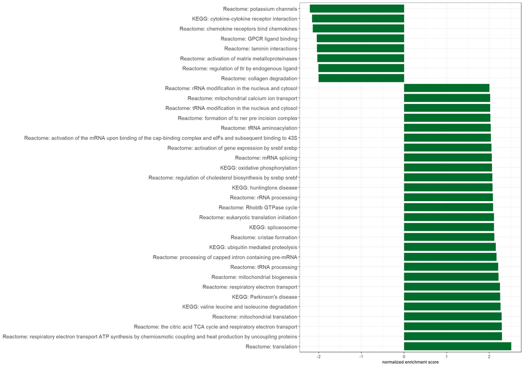

View leading edges in top pathways. Select top five pathways with positive and negative NES respectively

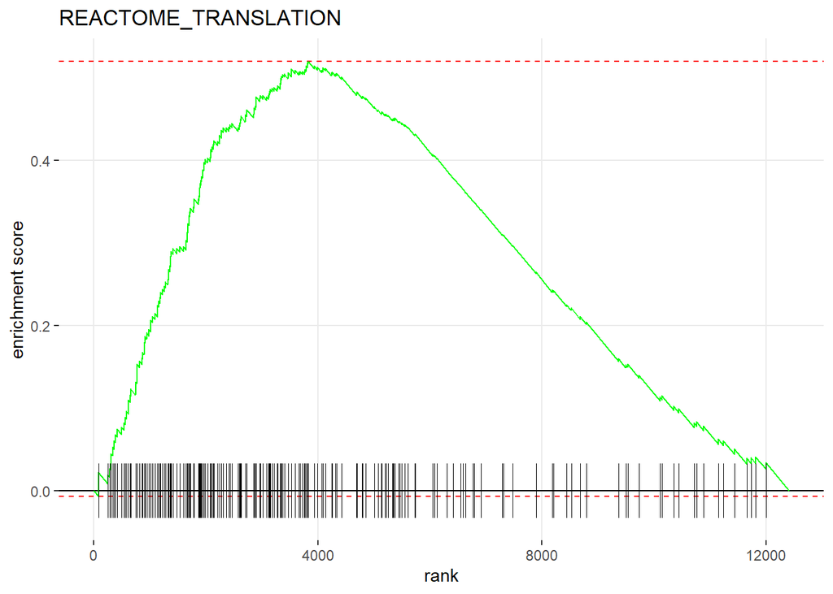

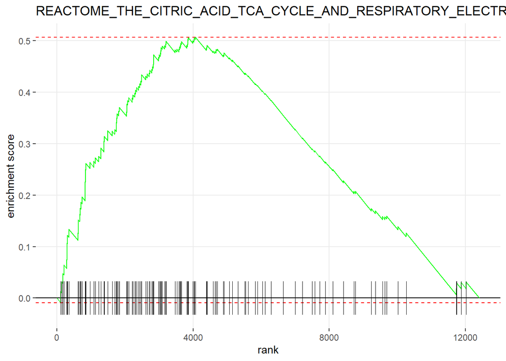

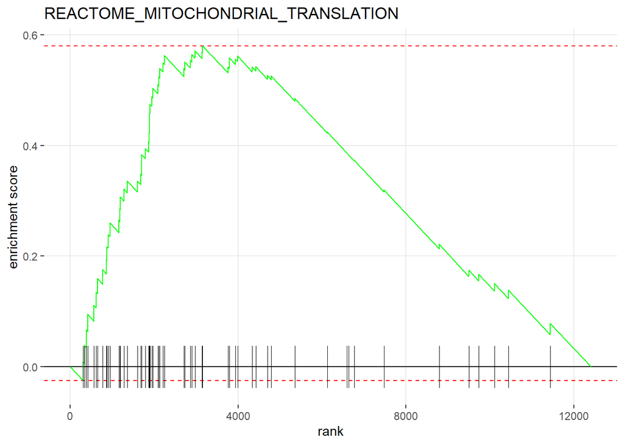

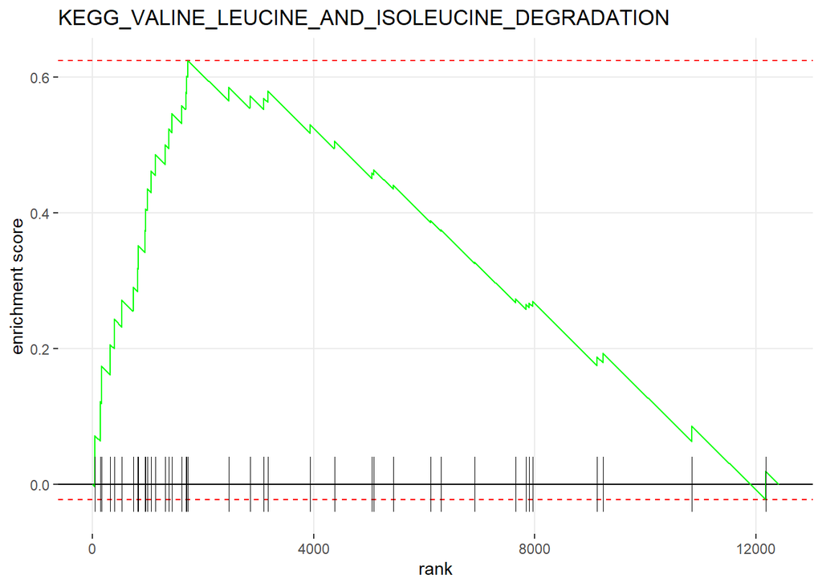

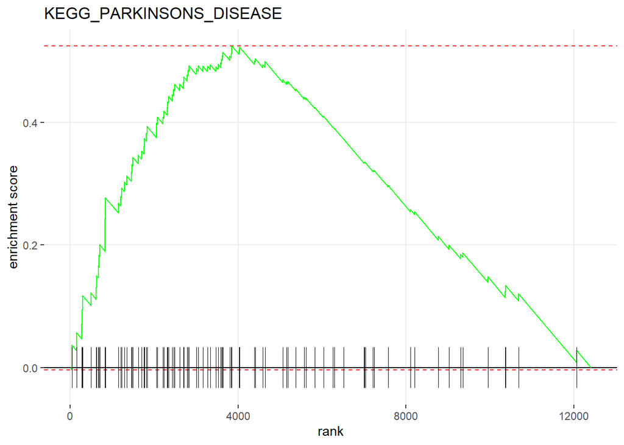

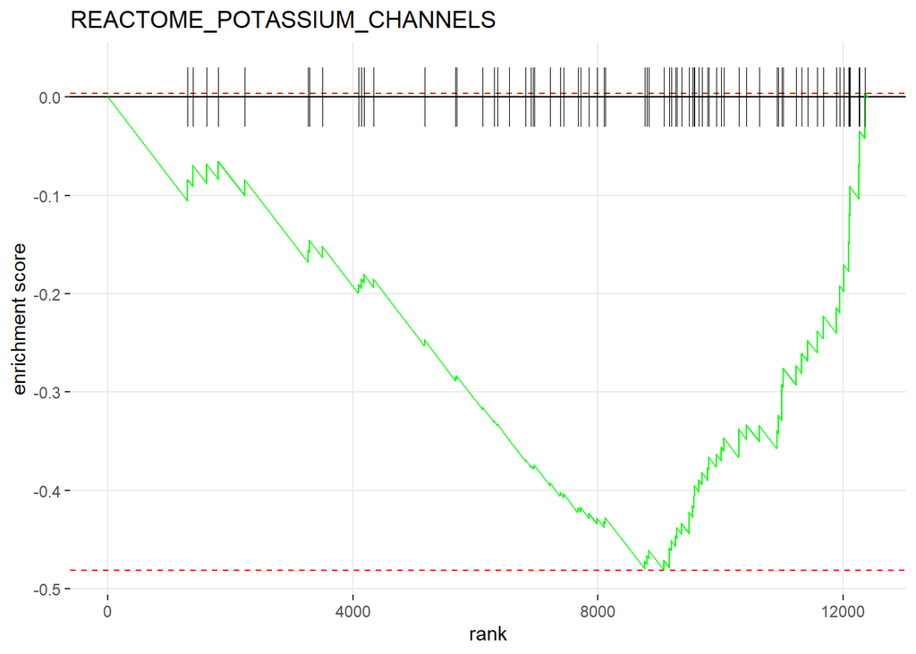

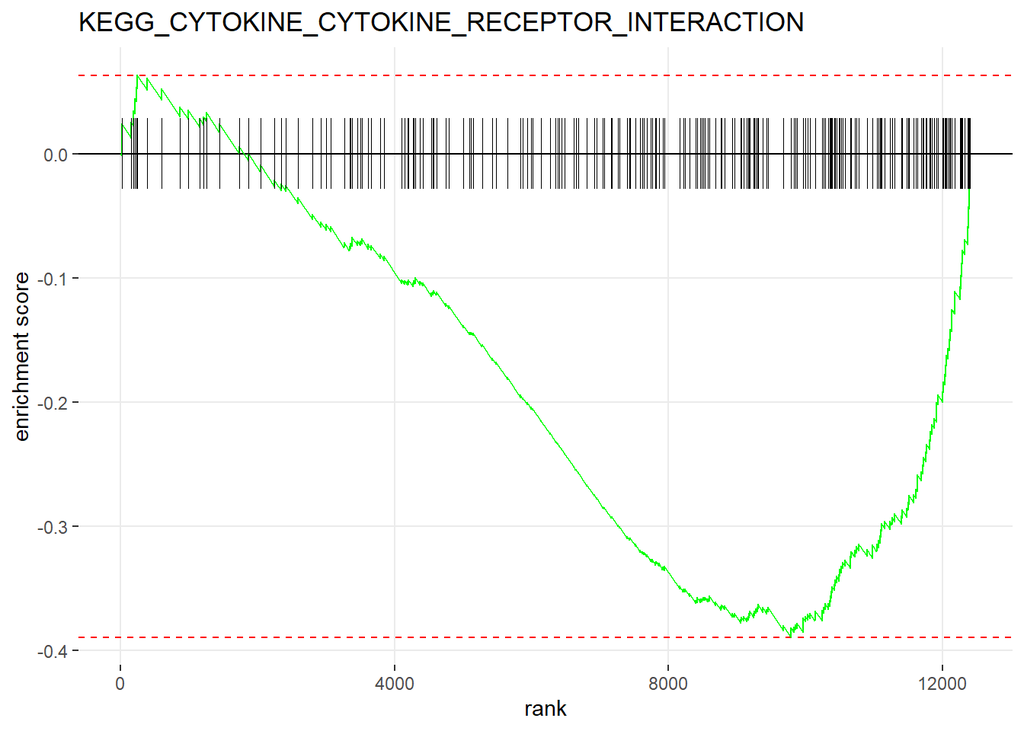

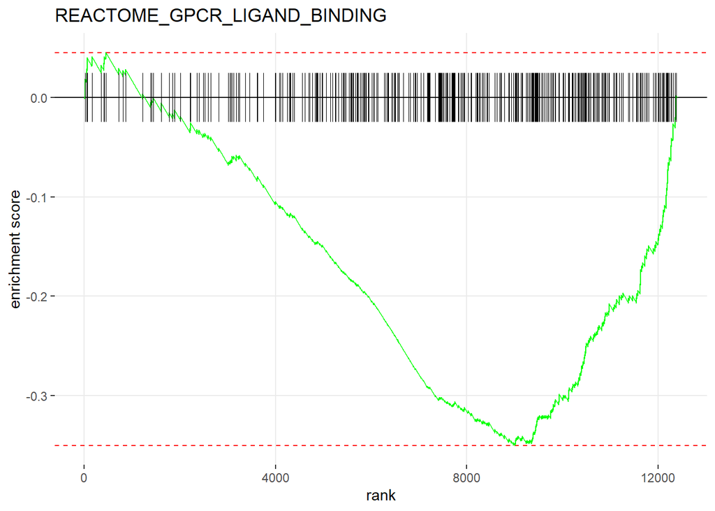

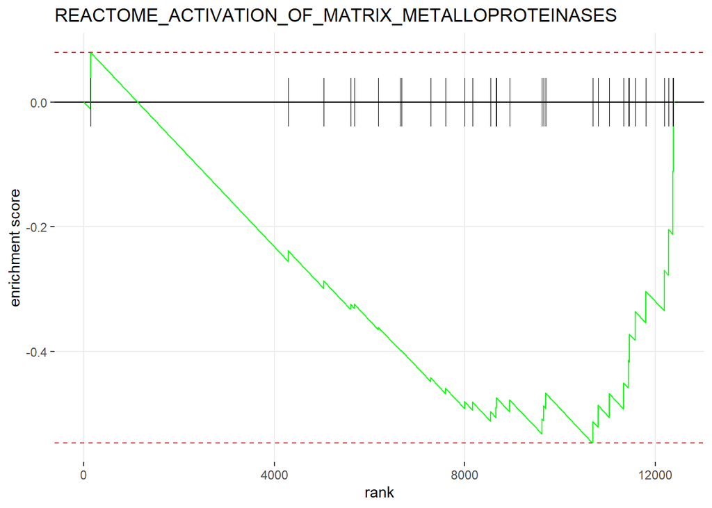

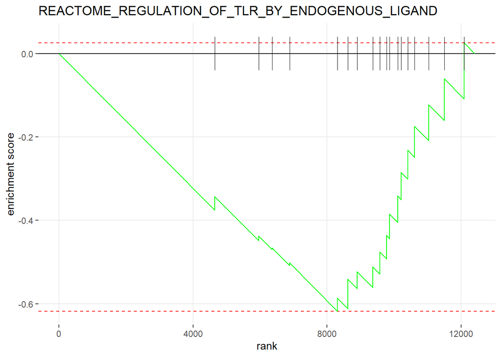

#### Session information

**R version 4.0.3 (2020-10-10)**

**Platform:** x86_64-w64-mingw32/x64 (64-bit)

**locale:** *LC_COLLATE=English_United States.1252*, *LC_CTYPE=English_United States.1252*, *LC_MONETARY=English_United States.1252*, *LC_NUMERIC=C* and *LC_TIME=English_United States.1252*

**attached base packages:** *stats4*, *parallel*, *stats*, *graphics*, *grDevices*, *utils*, *datasets*, *methods* and *base*

**other attached packages:** *hgu133a.db(v.3.2.3)*, *org.Hs.eg.db(v.3.11.4)*, *pd.hg.u133a(v.3.12.0)*, *DBI(v.1.1.0)*, *RSQLite(v.2.2.1)*, *biomaRt(v.2.44.4)*, *fgsea(v.1.14.0)*, *pander(v.0.6.3)*, *preprocessCore(v.1.50.0)*, *devtools(v.2.4.2)*, *usethis(v.2.0.1)*, *gplots(v.3.1.0)*, *ggplot2(v.3.3.5)*, *viridis(v.0.5.1)*, *viridisLite(v.0.3.0)*, *DT(v.0.16)*, *annotate(v.1.66.0)*, *XML(v.3.99-0.5)*, *AnnotationDbi(v.1.50.3)*, *sva(v.3.36.0)*, *BiocParallel(v.1.22.0)*, *genefilter(v.1.70.0)*, *mgcv(v.1.8-33)*, *nlme(v.3.1-149)*, *limma(v.3.44.3)*, *oligo(v.1.52.1)*, *Biostrings(v.2.56.0)*, *XVector(v.0.28.0)*, *IRanges(v.2.22.2)*, *S4Vectors(v.0.26.1)*, *oligoClasses(v.1.50.4)*, *GEOquery(v.2.56.0)*, *Biobase(v.2.48.0)* and *BiocGenerics(v.0.34.0)*

**loaded via a namespace (and not attached):** *colorspace(v.1.4-1)*, *ellipsis(v.0.3.2)*, *rprojroot(v.1.3-2)*, *GenomicRanges(v.1.40.0)*, *fs(v.1.5.0)*, *rstudioapi(v.0.13)*, *farver(v.2.0.3)*, *remotes(v.2.4.0)*, *affyio(v.1.58.0)*, *bit64(v.4.0.5)*, *fansi(v.0.4.1)*, *xml2(v.1.3.2)*, *codetools(v.0.2-16)*, *splines(v.4.0.3)*, *cachem(v.1.0.5)*, *knitr(v.1.30)*, *pkgload(v.1.2.1)*, *jsonlite(v.1.7.2)*, *dbplyr(v.2.1.1)*, *httr(v.1.4.2)*, *BiocManager(v.1.30.10)*, *readr(v.1.4.0)*, *compiler(v.4.0.3)*, *backports(v.1.1.10)*, *assertthat(v.0.2.1)*, *Matrix(v.1.2-18)*, *fastmap(v.1.0.1)*, *cli(v.2.5.0)*, *htmltools(v.0.5.0)*, *prettyunits(v.1.1.1)*, *tools(v.4.0.3)*, *gtable(v.0.3.0)*, *glue(v.1.4.2)*, *GenomeInfoDbData(v.1.2.3)*, *affxparser(v.1.60.0)*, *dplyr(v.1.0.5)*, *rappdirs(v.0.3.1)*, *fastmatch(v.1.1-0)*, *Rcpp(v.1.0.5)*, *vctrs(v.0.3.8)*, *crosstalk(v.1.1.0.1)*, *iterators(v.1.0.13)*, *xfun(v.0.18)*, *stringr(v.1.4.0)*, *ps(v.1.4.0)*, *testthat(v.3.0.4)*, *lifecycle(v.1.0.0)*, *gtools(v.3.8.2)*, *edgeR(v.3.30.3)*, *zlibbioc(v.1.34.0)*, *scales(v.1.1.1)*, *hms(v.1.1.0)*, *SummarizedExperiment(v.1.18.2)*, *curl(v.4.3)*, *yaml(v.2.2.1)*, *memoise(v.2.0.0)*, *gridExtra(v.2.3)*, *stringi(v.1.5.3)*, *desc(v.1.3.0)*, *foreach(v.1.5.1)*, *caTools(v.1.18.0)*, *pkgbuild(v.1.2.0)*, *GenomeInfoDb(v.1.24.2)*, *rlang(v.0.4.10)*, *pkgconfig(v.2.0.3)*, *matrixStats(v.0.57.0)*, *bitops(v.1.0-6)*, *evaluate(v.0.14)*, *lattice(v.0.20-41)*, *purrr(v.0.3.4)*, *labeling(v.0.4.2)*, *htmlwidgets(v.1.5.2)*, *bit(v.4.0.4)*, *tidyselect(v.1.1.0)*, *processx(v.3.5.2)*, *magrittr(v.2.0.1)*, *R6(v.2.4.1)*, *snow(v.0.4-3)*, *generics(v.0.1.0)*, *DelayedArray(v.0.14.1)*, *pillar(v.1.6.1)*, *withr(v.2.4.2)*, *survival(v.3.2-7)*, *RCurl(v.1.98-1.2)*, *tibble(v.3.0.4)*, *crayon(v.1.4.1)*, *KernSmooth(v.2.23-17)*, *utf8(v.1.1.4)*, *BiocFileCache(v.1.12.1)*, *rmarkdown(v.2.5)*, *progress(v.1.2.2)*, *locfit(v.1.5-9.4)*, *grid(v.4.0.3)*, *data.table(v.1.14.0)*, *blob(v.1.2.1)*, *callr(v.3.7.0)*, *digest(v.0.6.25)*, *xtable(v.1.8-4)*, *ff(v.4.0.4)*, *tidyr(v.1.1.3)*, *openssl(v.1.4.3)*, *munsell(v.0.5.0)*, *askpass(v.1.1)* and *sessioninfo(v.1.1.1)*